# Time series Analysis

### Analysing all three plots

The highest and lowest monthly death was recorded in 1976 for ldeaths which is the data that accounts the total of deaths in females and males. There has been constant fluctuation in the numbers over the months in various years but the overall behavior has been consistent.The trend towards 1979 end shows the numbers to be decreasing.

### Meta’s Prophet forecasting

```r
ldeaths.df = data.frame(ds=zoo::as.yearmon(time(ldeaths)),
                        y=ldeaths) #Create a dataframe with proper column names and format
deathmodel = prophet::prophet(ldeaths.df) #Initialize the prophet model
```

```
## Disabling weekly seasonality. Run prophet with weekly.seasonality=TRUE to override this.
```

```
## Disabling daily seasonality. Run prophet with daily.seasonality=TRUE to override this.
```

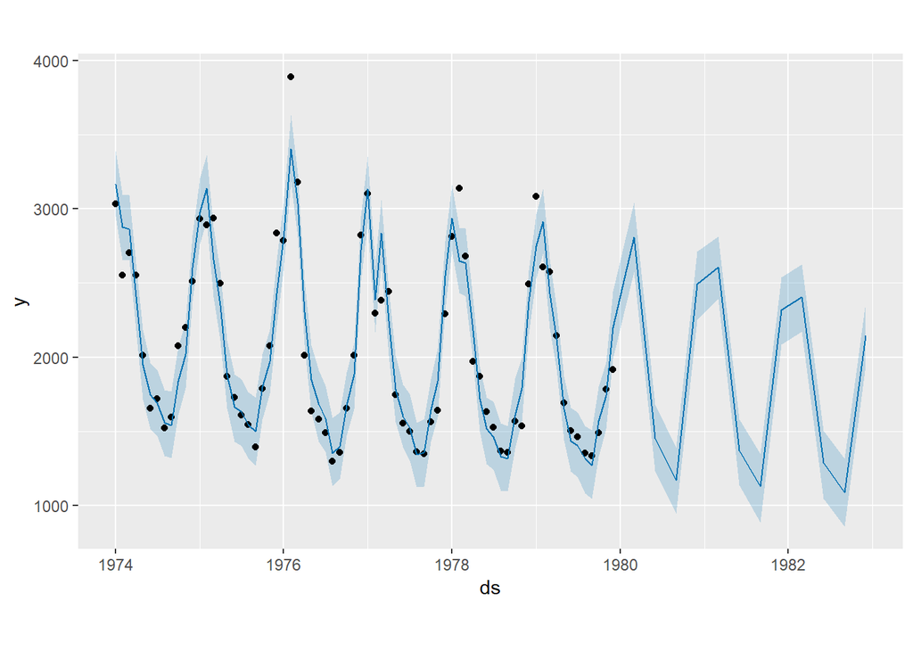

```r
future = prophet::make_future_dataframe(deathmodel, periods=12, freq="quarter") #Generate future dates for forecasting
forecast = predict (deathmodel,future)# Predict future values
plot(deathmodel,forecast)
```

```r
library(prophet)
```

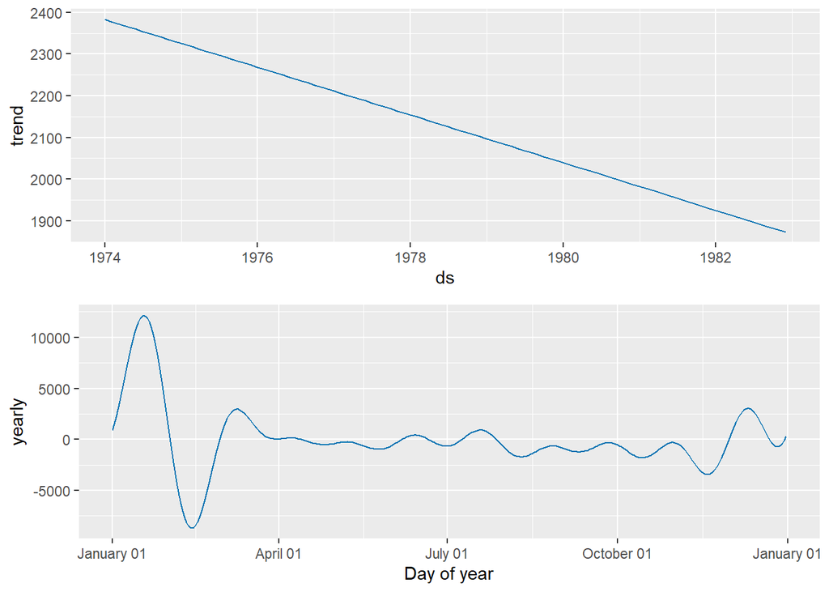

```r
prophet_plot_components(deathmodel,forecast) #Plot the other important components of the prophet model
```

The first graph tells us that there is decreasing trend from the year 1974 to 1983 and it is negative linear correlation. The second graph tells us about the yearly seasonality which shows that there is a peak period in start of the year but most of the year there is no seasonality and blue curvy line is close to zero.

### Exponential Smoothing

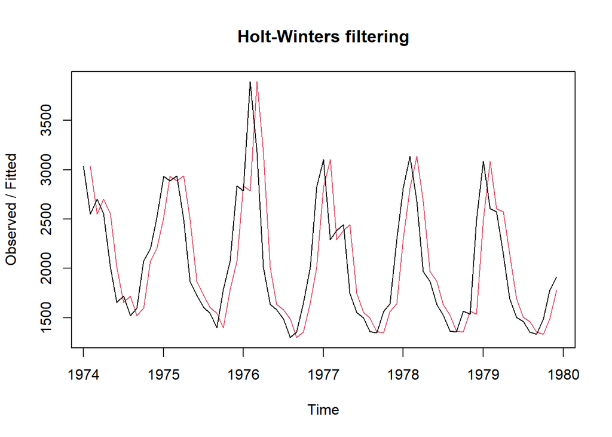

```r
exponentialmodel= HoltWinters(ldeaths,beta=FALSE,gamma =FALSE) #Exponetial smoothing
plot(exponentialmodel) #plotting the exponential model
```

```r
exponentialmodel
```

```
## Holt-Winters exponential smoothing without trend and without seasonal component.
##
## Call:
## HoltWinters(x = ldeaths, beta = FALSE, gamma = FALSE)
##
## Smoothing parameters:
##  alpha: 0.9999339
##  beta : FALSE
##  gamma: FALSE
##
## Coefficients:
##       [,1]
## a 1914.991
```

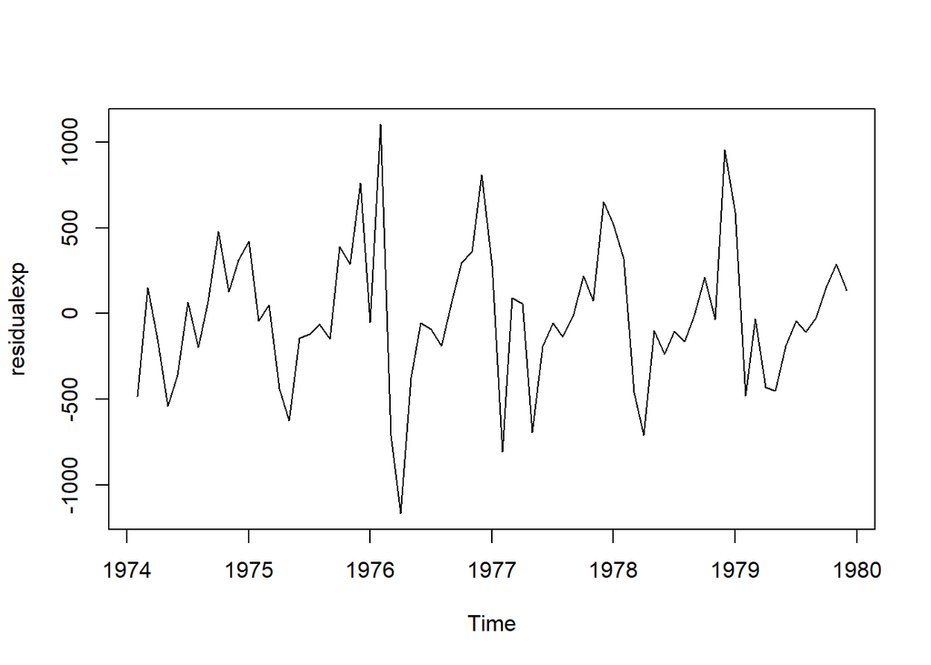

```r
residualexp= ldeaths - exponentialmodel$fitted[,1] #Residual
plot(residualexp)#Residual plots
```

```r
library(dygraphs)# load package
ldeaths<-cbind(mdeaths, fdeaths) #binds both female and male deaths into one matrix
dygraph(ldeaths) %>% #Generates time series plot
  dyRangeSelector() ##Allows to zoom in and out of graph
```

[interactive chart not shown]